# Risk Factor Analysis

## Outcome Variable

**Outcome Variable:** y_rate_wtkg

## Predictor Variables

**Intervention Variable:** exclfeed36

**Adjustment Set:**

unadjusted

## Stratifying Variables

The analysis was stratified on these variable(s):

- agecat
- studyid
- country

## Data Summary

| agecat | studyid | country | exclfeed36 | n_cell | n |
| --- | --- | --- | --- | --- | --- |
| 0-3 months | CMC-V-BCS-2002 | INDIA | 1 | 6 | 6 |
| 0-3 months | CMC-V-BCS-2002 | INDIA | 0 | 0 | 6 |
| 0-3 months | EE | PAKISTAN | 1 | 3 | 7 |
| 0-3 months | EE | PAKISTAN | 0 | 4 | 7 |
| 0-3 months | GMS-Nepal | NEPAL | 1 | 373 | 466 |
| 0-3 months | GMS-Nepal | NEPAL | 0 | 93 | 466 |
| 0-3 months | IRC | INDIA | 1 | 0 | 4 |
| 0-3 months | IRC | INDIA | 0 | 4 | 4 |
| 0-3 months | Keneba | GAMBIA | 1 | 400 | 1384 |
| 0-3 months | Keneba | GAMBIA | 0 | 984 | 1384 |
| 0-3 months | MAL-ED | BANGLADESH | 1 | 32 | 245 |
| 0-3 months | MAL-ED | BANGLADESH | 0 | 213 | 245 |
| 0-3 months | MAL-ED | BRAZIL | 1 | 14 | 217 |
| 0-3 months | MAL-ED | BRAZIL | 0 | 203 | 217 |
| 0-3 months | MAL-ED | INDIA | 1 | 10 | 235 |
| 0-3 months | MAL-ED | INDIA | 0 | 225 | 235 |
| 0-3 months | MAL-ED | NEPAL | 1 | 5 | 230 |
| 0-3 months | MAL-ED | NEPAL | 0 | 225 | 230 |
| 0-3 months | MAL-ED | PERU | 1 | 7 | 280 |
| 0-3 months | MAL-ED | PERU | 0 | 273 | 280 |
| 0-3 months | MAL-ED | SOUTH AFRICA | 1 | 3 | 268 |
| 0-3 months | MAL-ED | SOUTH AFRICA | 0 | 265 | 268 |
| 0-3 months | MAL-ED | TANZANIA, UNITED REPUBLIC OF | 1 | 3 | 232 |
| 0-3 months | MAL-ED | TANZANIA, UNITED REPUBLIC OF | 0 | 229 | 232 |
| 0-3 months | PROVIDE | BANGLADESH | 1 | 161 | 634 |
| 0-3 months | PROVIDE | BANGLADESH | 0 | 473 | 634 |
| 3-6 months | CMC-V-BCS-2002 | INDIA | 1 | 6 | 6 |
| 3-6 months | CMC-V-BCS-2002 | INDIA | 0 | 0 | 6 |
| 3-6 months | EE | PAKISTAN | 1 | 3 | 7 |
| 3-6 months | EE | PAKISTAN | 0 | 4 | 7 |

[output cut: 198 more lines]

The following strata were considered:

- agecat: 0-3 months, studyid: CMC-V-BCS-2002, country: INDIA
- agecat: 0-3 months, studyid: EE, country: PAKISTAN
- agecat: 0-3 months, studyid: GMS-Nepal, country: NEPAL
- agecat: 0-3 months, studyid: IRC, country: INDIA
- agecat: 0-3 months, studyid: Keneba, country: GAMBIA
- agecat: 0-3 months, studyid: MAL-ED, country: BANGLADESH
- agecat: 0-3 months, studyid: MAL-ED, country: BRAZIL
- agecat: 0-3 months, studyid: MAL-ED, country: INDIA
- agecat: 0-3 months, studyid: MAL-ED, country: NEPAL
- agecat: 0-3 months, studyid: MAL-ED, country: PERU
- agecat: 0-3 months, studyid: MAL-ED, country: SOUTH AFRICA
- agecat: 0-3 months, studyid: MAL-ED, country: TANZANIA, UNITED REPUBLIC OF
- agecat: 0-3 months, studyid: PROVIDE, country: BANGLADESH
- agecat: 12-15 months, studyid: CMC-V-BCS-2002, country: INDIA
- agecat: 12-15 months, studyid: EE, country: PAKISTAN
- agecat: 12-15 months, studyid: GMS-Nepal, country: NEPAL
- agecat: 12-15 months, studyid: IRC, country: INDIA
- agecat: 12-15 months, studyid: Keneba, country: GAMBIA
- agecat: 12-15 months, studyid: LCNI-5, country: MALAWI
- agecat: 12-15 months, studyid: MAL-ED, country: BANGLADESH
- agecat: 12-15 months, studyid: MAL-ED, country: BRAZIL
- agecat: 12-15 months, studyid: MAL-ED, country: INDIA
- agecat: 12-15 months, studyid: MAL-ED, country: NEPAL
- agecat: 12-15 months, studyid: MAL-ED, country: PERU
- agecat: 12-15 months, studyid: MAL-ED, country: SOUTH AFRICA
- agecat: 12-15 months, studyid: MAL-ED, country: TANZANIA, UNITED REPUBLIC OF
- agecat: 12-15 months, studyid: PROVIDE, country: BANGLADESH
- agecat: 12-15 months, studyid: SAS-FoodSuppl, country: INDIA
- agecat: 15-18 months, studyid: CMC-V-BCS-2002, country: INDIA
- agecat: 15-18 months, studyid: EE, country: PAKISTAN
- agecat: 15-18 months, studyid: GMS-Nepal, country: NEPAL
- agecat: 15-18 months, studyid: IRC, country: INDIA
- agecat: 15-18 months, studyid: Keneba, country: GAMBIA
- agecat: 15-18 months, studyid: LCNI-5, country: MALAWI
- agecat: 15-18 months, studyid: MAL-ED, country: BANGLADESH
- agecat: 15-18 months, studyid: MAL-ED, country: BRAZIL
- agecat: 15-18 months, studyid: MAL-ED, country: INDIA
- agecat: 15-18 months, studyid: MAL-ED, country: NEPAL
- agecat: 15-18 months, studyid: MAL-ED, country: PERU
- agecat: 15-18 months, studyid: MAL-ED, country: SOUTH AFRICA
- agecat: 15-18 months, studyid: MAL-ED, country: TANZANIA, UNITED REPUBLIC OF
- agecat: 15-18 months, studyid: PROVIDE, country: BANGLADESH
- agecat: 15-18 months, studyid: SAS-FoodSuppl, country: INDIA
- agecat: 18-21 months, studyid: CMC-V-BCS-2002, country: INDIA
- agecat: 18-21 months, studyid: EE, country: PAKISTAN
- agecat: 18-21 months, studyid: GMS-Nepal, country: NEPAL
- agecat: 18-21 months, studyid: IRC, country: INDIA
- agecat: 18-21 months, studyid: Keneba, country: GAMBIA
- agecat: 18-21 months, studyid: LCNI-5, country: MALAWI
- agecat: 18-21 months, studyid: MAL-ED, country: BANGLADESH
- agecat: 18-21 months, studyid: MAL-ED, country: BRAZIL
- agecat: 18-21 months, studyid: MAL-ED, country: INDIA
- agecat: 18-21 months, studyid: MAL-ED, country: NEPAL
- agecat: 18-21 months, studyid: MAL-ED, country: PERU
- agecat: 18-21 months, studyid: MAL-ED, country: SOUTH AFRICA
- agecat: 18-21 months, studyid: MAL-ED, country: TANZANIA, UNITED REPUBLIC OF
- agecat: 18-21 months, studyid: PROVIDE, country: BANGLADESH
- agecat: 21-24 months, studyid: CMC-V-BCS-2002, country: INDIA
- agecat: 21-24 months, studyid: EE, country: PAKISTAN
- agecat: 21-24 months, studyid: GMS-Nepal, country: NEPAL
- agecat: 21-24 months, studyid: IRC, country: INDIA
- agecat: 21-24 months, studyid: Keneba, country: GAMBIA
- agecat: 21-24 months, studyid: LCNI-5, country: MALAWI
- agecat: 21-24 months, studyid: MAL-ED, country: BANGLADESH
- agecat: 21-24 months, studyid: MAL-ED, country: BRAZIL
- agecat: 21-24 months, studyid: MAL-ED, country: INDIA
- agecat: 21-24 months, studyid: MAL-ED, country: NEPAL
- agecat: 21-24 months, studyid: MAL-ED, country: PERU
- agecat: 21-24 months, studyid: MAL-ED, country: SOUTH AFRICA
- agecat: 21-24 months, studyid: MAL-ED, country: TANZANIA, UNITED REPUBLIC OF
- agecat: 21-24 months, studyid: PROVIDE, country: BANGLADESH
- agecat: 3-6 months, studyid: CMC-V-BCS-2002, country: INDIA
- agecat: 3-6 months, studyid: EE, country: PAKISTAN
- agecat: 3-6 months, studyid: GMS-Nepal, country: NEPAL
- agecat: 3-6 months, studyid: IRC, country: INDIA
- agecat: 3-6 months, studyid: Keneba, country: GAMBIA
- agecat: 3-6 months, studyid: MAL-ED, country: BANGLADESH
- agecat: 3-6 months, studyid: MAL-ED, country: BRAZIL
- agecat: 3-6 months, studyid: MAL-ED, country: INDIA
- agecat: 3-6 months, studyid: MAL-ED, country: NEPAL
- agecat: 3-6 months, studyid: MAL-ED, country: PERU
- agecat: 3-6 months, studyid: MAL-ED, country: SOUTH AFRICA
- agecat: 3-6 months, studyid: MAL-ED, country: TANZANIA, UNITED REPUBLIC OF
- agecat: 3-6 months, studyid: PROVIDE, country: BANGLADESH
- agecat: 6-9 months, studyid: CMC-V-BCS-2002, country: INDIA
- agecat: 6-9 months, studyid: EE, country: PAKISTAN
- agecat: 6-9 months, studyid: GMS-Nepal, country: NEPAL
- agecat: 6-9 months, studyid: IRC, country: INDIA
- agecat: 6-9 months, studyid: Keneba, country: GAMBIA
- agecat: 6-9 months, studyid: LCNI-5, country: MALAWI
- agecat: 6-9 months, studyid: MAL-ED, country: BANGLADESH
- agecat: 6-9 months, studyid: MAL-ED, country: BRAZIL
- agecat: 6-9 months, studyid: MAL-ED, country: INDIA
- agecat: 6-9 months, studyid: MAL-ED, country: NEPAL
- agecat: 6-9 months, studyid: MAL-ED, country: PERU
- agecat: 6-9 months, studyid: MAL-ED, country: SOUTH AFRICA
- agecat: 6-9 months, studyid: MAL-ED, country: TANZANIA, UNITED REPUBLIC OF
- agecat: 6-9 months, studyid: PROVIDE, country: BANGLADESH
- agecat: 6-9 months, studyid: SAS-FoodSuppl, country: INDIA
- agecat: 9-12 months, studyid: CMC-V-BCS-2002, country: INDIA
- agecat: 9-12 months, studyid: EE, country: PAKISTAN
- agecat: 9-12 months, studyid: GMS-Nepal, country: NEPAL
- agecat: 9-12 months, studyid: IRC, country: INDIA
- agecat: 9-12 months, studyid: Keneba, country: GAMBIA
- agecat: 9-12 months, studyid: LCNI-5, country: MALAWI
- agecat: 9-12 months, studyid: MAL-ED, country: BANGLADESH
- agecat: 9-12 months, studyid: MAL-ED, country: BRAZIL
- agecat: 9-12 months, studyid: MAL-ED, country: INDIA
- agecat: 9-12 months, studyid: MAL-ED, country: NEPAL
- agecat: 9-12 months, studyid: MAL-ED, country: PERU
- agecat: 9-12 months, studyid: MAL-ED, country: SOUTH AFRICA
- agecat: 9-12 months, studyid: MAL-ED, country: TANZANIA, UNITED REPUBLIC OF
- agecat: 9-12 months, studyid: PROVIDE, country: BANGLADESH
- agecat: 9-12 months, studyid: SAS-FoodSuppl, country: INDIA

### Dropped Strata

Some strata were dropped due to rare outcomes:

- agecat: 0-3 months, studyid: CMC-V-BCS-2002, country: INDIA
- agecat: 0-3 months, studyid: EE, country: PAKISTAN
- agecat: 0-3 months, studyid: IRC, country: INDIA
- agecat: 0-3 months, studyid: MAL-ED, country: SOUTH AFRICA
- agecat: 0-3 months, studyid: MAL-ED, country: TANZANIA, UNITED REPUBLIC OF
- agecat: 3-6 months, studyid: CMC-V-BCS-2002, country: INDIA
- agecat: 3-6 months, studyid: EE, country: PAKISTAN
- agecat: 3-6 months, studyid: IRC, country: INDIA
- agecat: 3-6 months, studyid: MAL-ED, country: NEPAL
- agecat: 3-6 months, studyid: MAL-ED, country: SOUTH AFRICA
- agecat: 3-6 months, studyid: MAL-ED, country: TANZANIA, UNITED REPUBLIC OF
- agecat: 6-9 months, studyid: CMC-V-BCS-2002, country: INDIA
- agecat: 6-9 months, studyid: EE, country: PAKISTAN
- agecat: 6-9 months, studyid: IRC, country: INDIA
- agecat: 6-9 months, studyid: MAL-ED, country: NEPAL
- agecat: 6-9 months, studyid: MAL-ED, country: SOUTH AFRICA
- agecat: 6-9 months, studyid: MAL-ED, country: TANZANIA, UNITED REPUBLIC OF
- agecat: 6-9 months, studyid: SAS-FoodSuppl, country: INDIA
- agecat: 9-12 months, studyid: CMC-V-BCS-2002, country: INDIA
- agecat: 9-12 months, studyid: EE, country: PAKISTAN
- agecat: 9-12 months, studyid: IRC, country: INDIA
- agecat: 9-12 months, studyid: MAL-ED, country: NEPAL
- agecat: 9-12 months, studyid: MAL-ED, country: SOUTH AFRICA
- agecat: 9-12 months, studyid: MAL-ED, country: TANZANIA, UNITED REPUBLIC OF
- agecat: 9-12 months, studyid: SAS-FoodSuppl, country: INDIA
- agecat: 12-15 months, studyid: CMC-V-BCS-2002, country: INDIA
- agecat: 12-15 months, studyid: EE, country: PAKISTAN
- agecat: 12-15 months, studyid: IRC, country: INDIA
- agecat: 12-15 months, studyid: LCNI-5, country: MALAWI
- agecat: 12-15 months, studyid: MAL-ED, country: NEPAL
- agecat: 12-15 months, studyid: MAL-ED, country: SOUTH AFRICA
- agecat: 12-15 months, studyid: MAL-ED, country: TANZANIA, UNITED REPUBLIC OF
- agecat: 12-15 months, studyid: SAS-FoodSuppl, country: INDIA
- agecat: 15-18 months, studyid: CMC-V-BCS-2002, country: INDIA
- agecat: 15-18 months, studyid: EE, country: PAKISTAN
- agecat: 15-18 months, studyid: IRC, country: INDIA
- agecat: 15-18 months, studyid: LCNI-5, country: MALAWI
- agecat: 15-18 months, studyid: MAL-ED, country: NEPAL
- agecat: 15-18 months, studyid: MAL-ED, country: SOUTH AFRICA
- agecat: 15-18 months, studyid: MAL-ED, country: TANZANIA, UNITED REPUBLIC OF
- agecat: 15-18 months, studyid: SAS-FoodSuppl, country: INDIA
- agecat: 18-21 months, studyid: CMC-V-BCS-2002, country: INDIA
- agecat: 18-21 months, studyid: EE, country: PAKISTAN
- agecat: 18-21 months, studyid: IRC, country: INDIA
- agecat: 18-21 months, studyid: MAL-ED, country: NEPAL
- agecat: 18-21 months, studyid: MAL-ED, country: PERU
- agecat: 18-21 months, studyid: MAL-ED, country: SOUTH AFRICA
- agecat: 18-21 months, studyid: MAL-ED, country: TANZANIA, UNITED REPUBLIC OF
- agecat: 21-24 months, studyid: CMC-V-BCS-2002, country: INDIA
- agecat: 21-24 months, studyid: EE, country: PAKISTAN
- agecat: 21-24 months, studyid: IRC, country: INDIA
- agecat: 21-24 months, studyid: MAL-ED, country: NEPAL
- agecat: 21-24 months, studyid: MAL-ED, country: PERU
- agecat: 21-24 months, studyid: MAL-ED, country: SOUTH AFRICA
- agecat: 21-24 months, studyid: MAL-ED, country: TANZANIA, UNITED REPUBLIC OF

## Methods Detail

We’re interested in the causal parameters $E[Y_a]$ for all values of $a \in \mathcal{A}$. These parameters represent the mean outcome if, possibly contrary to fact, we intervened to set all units to have $A=a$. Under the randomization and positivity assumptions, these are identified by the statistical parameters $\psi_a=E_W[E_{Y|A,W}(Y|A=a,W)]$. In addition, we’re interested in the mean of $Y$, $E[Y]$ under no intervention (the observed mean). We will estimate these parameters by using SuperLearner to fit the relevant likelihood factors – $E_{Y|A,W}(Y|A=a,W)$ and $p(A=a|W)$, and then updating our likelihood fit using a joint TMLE.

For unadjusted analyses ($W=\{\}$), initial likelihoods were estimated using Lrnr_glm to estimate the simple $E(Y|A)$ and Lrnr_mean to estimate $p(A)$. For adjusted analyses, a small library containing Lrnr_glmnet, Lrnr_xgboost, and Lrnr_mean was used.

Having estimated these parameters, we will then use the delta method to estimate relative risks and attributable risks relative to a prespecified baseline level of $A$.

# Results Detail

## Results Plots

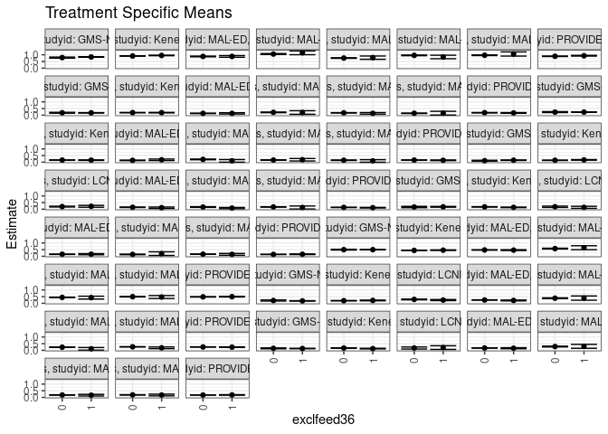

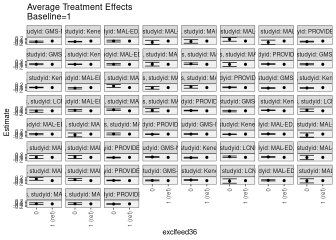

[figure not shown]

## Results Table

### Parameter: TSM

| agecat | studyid | country | intervention_level | baseline_level | estimate | ci_lower | ci_upper |
| --- | --- | --- | --- | --- | --- | --- | --- |
| 0-3 months | GMS-Nepal | NEPAL | 1 | NA | 0.8382463 | 0.8182606 | 0.8582321 |
| 0-3 months | GMS-Nepal | NEPAL | 0 | NA | 0.7922569 | 0.7535676 | 0.8309462 |
| 0-3 months | Keneba | GAMBIA | 1 | NA | 0.9536655 | 0.9331460 | 0.9741850 |
| 0-3 months | Keneba | GAMBIA | 0 | NA | 0.9127427 | 0.8985814 | 0.9269041 |
| 0-3 months | MAL-ED | BANGLADESH | 1 | NA | 0.8811539 | 0.8202359 | 0.9420720 |
| 0-3 months | MAL-ED | BANGLADESH | 0 | NA | 0.8791093 | 0.8541265 | 0.9040921 |
| 0-3 months | MAL-ED | BRAZIL | 1 | NA | 1.1537402 | 1.0087610 | 1.2987195 |
| 0-3 months | MAL-ED | BRAZIL | 0 | NA | 1.0594288 | 1.0242433 | 1.0946143 |
| 0-3 months | MAL-ED | INDIA | 1 | NA | 0.7865209 | 0.6625842 | 0.9104575 |
| 0-3 months | MAL-ED | INDIA | 0 | NA | 0.7576177 | 0.7348557 | 0.7803798 |
| 0-3 months | MAL-ED | NEPAL | 1 | NA | 0.8372995 | 0.7064060 | 0.9681929 |
| 0-3 months | MAL-ED | NEPAL | 0 | NA | 0.9593001 | 0.9319184 | 0.9866818 |
| 0-3 months | MAL-ED | PERU | 1 | NA | 1.0619875 | 0.9042981 | 1.2196769 |
| 0-3 months | MAL-ED | PERU | 0 | NA | 0.9686296 | 0.9431775 | 0.9940816 |
| 0-3 months | PROVIDE | BANGLADESH | 1 | NA | 0.9313025 | 0.9048491 | 0.9577559 |
| 0-3 months | PROVIDE | BANGLADESH | 0 | NA | 0.8926254 | 0.8753799 | 0.9098709 |
| 3-6 months | GMS-Nepal | NEPAL | 1 | NA | 0.4969046 | 0.4808220 | 0.5129873 |
| 3-6 months | GMS-Nepal | NEPAL | 0 | NA | 0.4972205 | 0.4696583 | 0.5247827 |
| 3-6 months | Keneba | GAMBIA | 1 | NA | 0.4579705 | 0.4385124 | 0.4774285 |
| 3-6 months | Keneba | GAMBIA | 0 | NA | 0.4424451 | 0.4309693 | 0.4539208 |
| 3-6 months | MAL-ED | BANGLADESH | 1 | NA | 0.4624104 | 0.4320984 | 0.4927224 |
| 3-6 months | MAL-ED | BANGLADESH | 0 | NA | 0.4757855 | 0.4571468 | 0.4944242 |
| 3-6 months | MAL-ED | BRAZIL | 1 | NA | 0.6435037 | 0.4940347 | 0.7929727 |
| 3-6 months | MAL-ED | BRAZIL | 0 | NA | 0.5741992 | 0.5424338 | 0.6059647 |
| 3-6 months | MAL-ED | INDIA | 1 | NA | 0.4279072 | 0.3201283 | 0.5356861 |
| 3-6 months | MAL-ED | INDIA | 0 | NA | 0.4443757 | 0.4266827 | 0.4620687 |
| 3-6 months | MAL-ED | PERU | 1 | NA | 0.4723659 | 0.3597202 | 0.5850116 |
| 3-6 months | MAL-ED | PERU | 0 | NA | 0.4988281 | 0.4796094 | 0.5180469 |
| 3-6 months | PROVIDE | BANGLADESH | 1 | NA | 0.4991535 | 0.4746240 | 0.5236830 |
| 3-6 months | PROVIDE | BANGLADESH | 0 | NA | 0.4858810 | 0.4705620 | 0.5012000 |

[output cut: 88 more lines]

### Parameter: E(Y)

| agecat | studyid | country | intervention_level | baseline_level | estimate | ci_lower | ci_upper |
| --- | --- | --- | --- | --- | --- | --- | --- |
| 0-3 months | GMS-Nepal | NEPAL | NA | NA | 0.8290682 | 0.8112267 | 0.8469097 |
| 0-3 months | Keneba | GAMBIA | NA | NA | 0.9245701 | 0.9128441 | 0.9362962 |
| 0-3 months | MAL-ED | BANGLADESH | NA | NA | 0.8793764 | 0.8562449 | 0.9025078 |
| 0-3 months | MAL-ED | BRAZIL | NA | NA | 1.0655134 | 1.0311555 | 1.0998713 |
| 0-3 months | MAL-ED | INDIA | NA | NA | 0.7588477 | 0.7364127 | 0.7812826 |
| 0-3 months | MAL-ED | NEPAL | NA | NA | 0.9566479 | 0.9296524 | 0.9836434 |
| 0-3 months | MAL-ED | PERU | NA | NA | 0.9709635 | 0.9457785 | 0.9961485 |
| 0-3 months | PROVIDE | BANGLADESH | NA | NA | 0.9024472 | 0.8878738 | 0.9170206 |
| 3-6 months | GMS-Nepal | NEPAL | NA | NA | 0.4969685 | 0.4829796 | 0.5109574 |
| 3-6 months | Keneba | GAMBIA | NA | NA | 0.4465835 | 0.4366897 | 0.4564773 |
| 3-6 months | MAL-ED | BANGLADESH | NA | NA | 0.4740560 | 0.4573508 | 0.4907612 |
| 3-6 months | MAL-ED | BRAZIL | NA | NA | 0.5781976 | 0.5469697 | 0.6094254 |
| 3-6 months | MAL-ED | INDIA | NA | NA | 0.4437256 | 0.4262017 | 0.4612496 |
| 3-6 months | MAL-ED | PERU | NA | NA | 0.4982335 | 0.4792789 | 0.5171881 |
| 3-6 months | PROVIDE | BANGLADESH | NA | NA | 0.4890611 | 0.4760060 | 0.5021163 |
| 6-9 months | GMS-Nepal | NEPAL | NA | NA | 0.1871486 | 0.1748771 | 0.1994201 |
| 6-9 months | Keneba | GAMBIA | NA | NA | 0.2005067 | 0.1873236 | 0.2136898 |
| 6-9 months | LCNI-5 | MALAWI | NA | NA | 0.2829175 | 0.2578313 | 0.3080037 |
| 6-9 months | MAL-ED | BANGLADESH | NA | NA | 0.2428552 | 0.2283339 | 0.2573765 |
| 6-9 months | MAL-ED | BRAZIL | NA | NA | 0.3831499 | 0.3570859 | 0.4092138 |
| 6-9 months | MAL-ED | INDIA | NA | NA | 0.2306231 | 0.2156296 | 0.2456166 |
| 6-9 months | MAL-ED | PERU | NA | NA | 0.2613933 | 0.2459015 | 0.2768851 |
| 6-9 months | PROVIDE | BANGLADESH | NA | NA | 0.2491653 | 0.2371134 | 0.2612172 |
| 9-12 months | GMS-Nepal | NEPAL | NA | NA | 0.1395865 | 0.1265823 | 0.1525906 |
| 9-12 months | Keneba | GAMBIA | NA | NA | 0.1608923 | 0.1478424 | 0.1739422 |
| 9-12 months | LCNI-5 | MALAWI | NA | NA | 0.1849664 | 0.1167599 | 0.2531730 |
| 9-12 months | MAL-ED | BANGLADESH | NA | NA | 0.1730346 | 0.1593686 | 0.1867006 |
| 9-12 months | MAL-ED | BRAZIL | NA | NA | 0.2845923 | 0.2527896 | 0.3163950 |
| 9-12 months | MAL-ED | INDIA | NA | NA | 0.1787492 | 0.1645237 | 0.1929747 |
| 9-12 months | MAL-ED | PERU | NA | NA | 0.1874806 | 0.1721694 | 0.2027919 |
| 9-12 months | PROVIDE | BANGLADESH | NA | NA | 0.1780389 | 0.1687408 | 0.1873370 |
| 12-15 months | GMS-Nepal | NEPAL | NA | NA | 0.1746639 | 0.1610783 | 0.1882495 |
| 12-15 months | Keneba | GAMBIA | NA | NA | 0.1891400 | 0.1785232 | 0.1997569 |
| 12-15 months | MAL-ED | BANGLADESH | NA | NA | 0.1353586 | 0.1195861 | 0.1511312 |
| 12-15 months | MAL-ED | BRAZIL | NA | NA | 0.2101946 | 0.1853699 | 0.2350192 |
| 12-15 months | MAL-ED | INDIA | NA | NA | 0.1739653 | 0.1578765 | 0.1900541 |
| 12-15 months | MAL-ED | PERU | NA | NA | 0.1417390 | 0.1250455 | 0.1584325 |
| 12-15 months | PROVIDE | BANGLADESH | NA | NA | 0.1796101 | 0.1678900 | 0.1913301 |
| 15-18 months | GMS-Nepal | NEPAL | NA | NA | 0.2291397 | 0.2134657 | 0.2448138 |
| 15-18 months | Keneba | GAMBIA | NA | NA | 0.1573149 | 0.1464971 | 0.1681327 |
| 15-18 months | MAL-ED | BANGLADESH | NA | NA | 0.1427882 | 0.1271818 | 0.1583946 |
| 15-18 months | MAL-ED | BRAZIL | NA | NA | 0.2034195 | 0.1767881 | 0.2300509 |
| 15-18 months | MAL-ED | INDIA | NA | NA | 0.1642299 | 0.1493519 | 0.1791079 |
| 15-18 months | MAL-ED | PERU | NA | NA | 0.1461889 | 0.1273267 | 0.1650511 |
| 15-18 months | PROVIDE | BANGLADESH | NA | NA | 0.1558862 | 0.1440925 | 0.1676799 |
| 18-21 months | GMS-Nepal | NEPAL | NA | NA | 0.1428759 | 0.1266216 | 0.1591302 |
| 18-21 months | Keneba | GAMBIA | NA | NA | 0.1526855 | 0.1413636 | 0.1640074 |
| 18-21 months | LCNI-5 | MALAWI | NA | NA | 0.2016785 | 0.1726437 | 0.2307133 |
| 18-21 months | MAL-ED | BANGLADESH | NA | NA | 0.1427146 | 0.1257942 | 0.1596351 |
| 18-21 months | MAL-ED | BRAZIL | NA | NA | 0.1606491 | 0.1365241 | 0.1847741 |
| 18-21 months | MAL-ED | INDIA | NA | NA | 0.1701596 | 0.1556514 | 0.1846677 |
| 18-21 months | PROVIDE | BANGLADESH | NA | NA | 0.1324685 | 0.1209911 | 0.1439458 |
| 21-24 months | GMS-Nepal | NEPAL | NA | NA | 0.1784694 | 0.1533807 | 0.2035582 |
| 21-24 months | Keneba | GAMBIA | NA | NA | 0.1661358 | 0.1549650 | 0.1773065 |
| 21-24 months | LCNI-5 | MALAWI | NA | NA | 0.1779746 | 0.1356818 | 0.2202674 |
| 21-24 months | MAL-ED | BANGLADESH | NA | NA | 0.1521155 | 0.1369898 | 0.1672413 |
| 21-24 months | MAL-ED | BRAZIL | NA | NA | 0.1434900 | 0.1201394 | 0.1668407 |
| 21-24 months | MAL-ED | INDIA | NA | NA | 0.1565193 | 0.1433011 | 0.1697376 |
| 21-24 months | PROVIDE | BANGLADESH | NA | NA | 0.1419760 | 0.1304951 | 0.1534569 |

### Parameter: ATE

| agecat | studyid | country | intervention_level | baseline_level | estimate | ci_lower | ci_upper |
| --- | --- | --- | --- | --- | --- | --- | --- |
| 0-3 months | GMS-Nepal | NEPAL | 1 | 1 | 0.0000000 | 0.0000000 | 0.0000000 |
| 0-3 months | GMS-Nepal | NEPAL | 0 | 1 | -0.0459894 | -0.0895359 | -0.0024430 |
| 0-3 months | Keneba | GAMBIA | 1 | 1 | 0.0000000 | 0.0000000 | 0.0000000 |
| 0-3 months | Keneba | GAMBIA | 0 | 1 | -0.0409227 | -0.0658545 | -0.0159910 |
| 0-3 months | MAL-ED | BANGLADESH | 1 | 1 | 0.0000000 | 0.0000000 | 0.0000000 |
| 0-3 months | MAL-ED | BANGLADESH | 0 | 1 | -0.0020446 | -0.0678865 | 0.0637972 |
| 0-3 months | MAL-ED | BRAZIL | 1 | 1 | 0.0000000 | 0.0000000 | 0.0000000 |
| 0-3 months | MAL-ED | BRAZIL | 0 | 1 | -0.0943114 | -0.2434993 | 0.0548764 |
| 0-3 months | MAL-ED | INDIA | 1 | 1 | 0.0000000 | 0.0000000 | 0.0000000 |
| 0-3 months | MAL-ED | INDIA | 0 | 1 | -0.0289031 | -0.1549127 | 0.0971064 |
| 0-3 months | MAL-ED | NEPAL | 1 | 1 | 0.0000000 | 0.0000000 | 0.0000000 |
| 0-3 months | MAL-ED | NEPAL | 0 | 1 | 0.1220006 | -0.0117262 | 0.2557274 |
| 0-3 months | MAL-ED | PERU | 1 | 1 | 0.0000000 | 0.0000000 | 0.0000000 |
| 0-3 months | MAL-ED | PERU | 0 | 1 | -0.0933579 | -0.2530882 | 0.0663723 |
| 0-3 months | PROVIDE | BANGLADESH | 1 | 1 | 0.0000000 | 0.0000000 | 0.0000000 |
| 0-3 months | PROVIDE | BANGLADESH | 0 | 1 | -0.0386771 | -0.0702554 | -0.0070988 |
| 3-6 months | GMS-Nepal | NEPAL | 1 | 1 | 0.0000000 | 0.0000000 | 0.0000000 |
| 3-6 months | GMS-Nepal | NEPAL | 0 | 1 | 0.0003159 | -0.0315953 | 0.0322271 |
| 3-6 months | Keneba | GAMBIA | 1 | 1 | 0.0000000 | 0.0000000 | 0.0000000 |
| 3-6 months | Keneba | GAMBIA | 0 | 1 | -0.0155254 | -0.0381154 | 0.0070646 |
| 3-6 months | MAL-ED | BANGLADESH | 1 | 1 | 0.0000000 | 0.0000000 | 0.0000000 |
| 3-6 months | MAL-ED | BANGLADESH | 0 | 1 | 0.0133751 | -0.0222089 | 0.0489591 |
| 3-6 months | MAL-ED | BRAZIL | 1 | 1 | 0.0000000 | 0.0000000 | 0.0000000 |
| 3-6 months | MAL-ED | BRAZIL | 0 | 1 | -0.0693045 | -0.2221117 | 0.0835027 |
| 3-6 months | MAL-ED | INDIA | 1 | 1 | 0.0000000 | 0.0000000 | 0.0000000 |
| 3-6 months | MAL-ED | INDIA | 0 | 1 | 0.0164685 | -0.0927529 | 0.1256900 |
| 3-6 months | MAL-ED | PERU | 1 | 1 | 0.0000000 | 0.0000000 | 0.0000000 |
| 3-6 months | MAL-ED | PERU | 0 | 1 | 0.0264622 | -0.0878112 | 0.1407356 |
| 3-6 months | PROVIDE | BANGLADESH | 1 | 1 | 0.0000000 | 0.0000000 | 0.0000000 |
| 3-6 months | PROVIDE | BANGLADESH | 0 | 1 | -0.0132724 | -0.0421925 | 0.0156476 |

[output cut: 88 more lines]

### Parameter: PAR

| agecat | studyid | country | intervention_level | baseline_level | estimate | ci_lower | ci_upper |
| --- | --- | --- | --- | --- | --- | --- | --- |
| 0-3 months | GMS-Nepal | NEPAL | 1 | NA | -0.0091782 | -0.0180279 | -0.0003284 |
| 0-3 months | Keneba | GAMBIA | 1 | NA | -0.0290954 | -0.0468484 | -0.0113423 |
| 0-3 months | MAL-ED | BANGLADESH | 1 | NA | -0.0017776 | -0.0590197 | 0.0554646 |
| 0-3 months | MAL-ED | BRAZIL | 1 | NA | -0.0882268 | -0.2278238 | 0.0513702 |
| 0-3 months | MAL-ED | INDIA | 1 | NA | -0.0276732 | -0.1483229 | 0.0929765 |
| 0-3 months | MAL-ED | NEPAL | 1 | NA | 0.1193484 | -0.0110556 | 0.2497524 |
| 0-3 months | MAL-ED | PERU | 1 | NA | -0.0910240 | -0.2467704 | 0.0647224 |
| 0-3 months | PROVIDE | BANGLADESH | 1 | NA | -0.0288553 | -0.0524510 | -0.0052596 |
| 3-6 months | GMS-Nepal | NEPAL | 1 | NA | 0.0000639 | -0.0063878 | 0.0065155 |
| 3-6 months | Keneba | GAMBIA | 1 | NA | -0.0113869 | -0.0279596 | 0.0051857 |
| 3-6 months | MAL-ED | BANGLADESH | 1 | NA | 0.0116455 | -0.0193425 | 0.0426335 |
| 3-6 months | MAL-ED | BRAZIL | 1 | NA | -0.0653062 | -0.2093143 | 0.0787020 |
| 3-6 months | MAL-ED | INDIA | 1 | NA | 0.0158185 | -0.0890925 | 0.1207294 |
| 3-6 months | MAL-ED | PERU | 1 | NA | 0.0258676 | -0.0855500 | 0.1372851 |
| 3-6 months | PROVIDE | BANGLADESH | 1 | NA | -0.0100923 | -0.0320878 | 0.0119031 |
| 6-9 months | GMS-Nepal | NEPAL | 1 | NA | 0.0052710 | -0.0027172 | 0.0132592 |
| 6-9 months | Keneba | GAMBIA | 1 | NA | -0.0143946 | -0.0369151 | 0.0081259 |
| 6-9 months | LCNI-5 | MALAWI | 1 | NA | 0.0396105 | -0.0022362 | 0.0814572 |
| 6-9 months | MAL-ED | BANGLADESH | 1 | NA | 0.0280363 | -0.0036913 | 0.0597638 |
| 6-9 months | MAL-ED | BRAZIL | 1 | NA | -0.0090931 | -0.1606740 | 0.1424877 |
| 6-9 months | MAL-ED | INDIA | 1 | NA | 0.1170074 | 0.0219593 | 0.2120555 |
| 6-9 months | MAL-ED | PERU | 1 | NA | 0.0729598 | 0.0082049 | 0.1377146 |
| 6-9 months | PROVIDE | BANGLADESH | 1 | NA | 0.0105622 | -0.0091237 | 0.0302481 |
| 9-12 months | GMS-Nepal | NEPAL | 1 | NA | 0.0024045 | -0.0039010 | 0.0087100 |
| 9-12 months | Keneba | GAMBIA | 1 | NA | 0.0304246 | 0.0103540 | 0.0504952 |
| 9-12 months | LCNI-5 | MALAWI | 1 | NA | -0.0211070 | -0.1278851 | 0.0856710 |
| 9-12 months | MAL-ED | BANGLADESH | 1 | NA | 0.0151172 | -0.0213788 | 0.0516131 |
| 9-12 months | MAL-ED | BRAZIL | 1 | NA | -0.0173242 | -0.1587537 | 0.1241053 |
| 9-12 months | MAL-ED | INDIA | 1 | NA | 0.0135163 | -0.0490419 | 0.0760744 |
| 9-12 months | MAL-ED | PERU | 1 | NA | 0.0105296 | -0.0547125 | 0.0757717 |
| 9-12 months | PROVIDE | BANGLADESH | 1 | NA | -0.0067679 | -0.0238751 | 0.0103392 |
| 12-15 months | GMS-Nepal | NEPAL | 1 | NA | 0.0009765 | -0.0057909 | 0.0077439 |
| 12-15 months | Keneba | GAMBIA | 1 | NA | 0.0008841 | -0.0156071 | 0.0173754 |
| 12-15 months | MAL-ED | BANGLADESH | 1 | NA | 0.0002885 | -0.0438136 | 0.0443907 |
| 12-15 months | MAL-ED | BRAZIL | 1 | NA | 0.0103752 | -0.1174619 | 0.1382124 |
| 12-15 months | MAL-ED | INDIA | 1 | NA | 0.0374922 | -0.0216640 | 0.0966484 |
| 12-15 months | MAL-ED | PERU | 1 | NA | -0.0078303 | -0.1474527 | 0.1317921 |
| 12-15 months | PROVIDE | BANGLADESH | 1 | NA | 0.0119897 | -0.0096456 | 0.0336250 |
| 15-18 months | GMS-Nepal | NEPAL | 1 | NA | 0.0003077 | -0.0075760 | 0.0081913 |
| 15-18 months | Keneba | GAMBIA | 1 | NA | 0.0039531 | -0.0120511 | 0.0199572 |
| 15-18 months | MAL-ED | BANGLADESH | 1 | NA | -0.0393154 | -0.0903543 | 0.0117234 |
| 15-18 months | MAL-ED | BRAZIL | 1 | NA | 0.1035488 | 0.0086476 | 0.1984501 |
| 15-18 months | MAL-ED | INDIA | 1 | NA | -0.0209181 | -0.1117417 | 0.0699055 |
| 15-18 months | MAL-ED | PERU | 1 | NA | 0.0524610 | -0.0422757 | 0.1471977 |
| 15-18 months | PROVIDE | BANGLADESH | 1 | NA | 0.0117832 | -0.0090138 | 0.0325803 |
| 18-21 months | GMS-Nepal | NEPAL | 1 | NA | -0.0068567 | -0.0142075 | 0.0004941 |
| 18-21 months | Keneba | GAMBIA | 1 | NA | -0.0193623 | -0.0367571 | -0.0019675 |
| 18-21 months | LCNI-5 | MALAWI | 1 | NA | -0.0182813 | -0.0826623 | 0.0460998 |
| 18-21 months | MAL-ED | BANGLADESH | 1 | NA | 0.0282727 | -0.0189479 | 0.0754934 |
| 18-21 months | MAL-ED | BRAZIL | 1 | NA | 0.0750205 | 0.0258975 | 0.1241436 |
| 18-21 months | MAL-ED | INDIA | 1 | NA | 0.0402515 | -0.0700091 | 0.1505121 |
| 18-21 months | PROVIDE | BANGLADESH | 1 | NA | 0.0161803 | -0.0036425 | 0.0360031 |
| 21-24 months | GMS-Nepal | NEPAL | 1 | NA | -0.0028863 | -0.0129132 | 0.0071406 |
| 21-24 months | Keneba | GAMBIA | 1 | NA | 0.0264263 | 0.0094271 | 0.0434254 |
| 21-24 months | LCNI-5 | MALAWI | 1 | NA | 0.0355803 | -0.0389438 | 0.1101043 |
| 21-24 months | MAL-ED | BANGLADESH | 1 | NA | -0.0038908 | -0.0444380 | 0.0366564 |
| 21-24 months | MAL-ED | BRAZIL | 1 | NA | -0.0542700 | -0.1836655 | 0.0751255 |
| 21-24 months | MAL-ED | INDIA | 1 | NA | 0.0115253 | -0.0544118 | 0.0774624 |
| 21-24 months | PROVIDE | BANGLADESH | 1 | NA | -0.0091982 | -0.0297911 | 0.0113948 |